# hw1

PHY 410 - HW1 - Andrew Koren

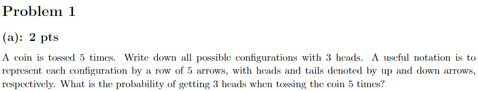

$$ \downarrow\downarrow\uparrow\uparrow\uparrow\quad \downarrow\uparrow\downarrow\uparrow\uparrow\\ \downarrow\uparrow\uparrow\downarrow\uparrow\quad \downarrow\uparrow\uparrow\uparrow\downarrow\\ \uparrow\downarrow\downarrow\uparrow\uparrow\quad \uparrow\downarrow\uparrow\downarrow\uparrow\\ \uparrow\downarrow\uparrow\uparrow\downarrow\quad \uparrow\uparrow\downarrow\downarrow\uparrow\\ \uparrow\uparrow\downarrow\uparrow\downarrow\quad \uparrow\uparrow\uparrow\downarrow\downarrow\\ $$

There are 10 ways to get 3 heads, and $2^5=32$ possible combinations, so the odds of getting three heads is $10/32 \approx 0.32$

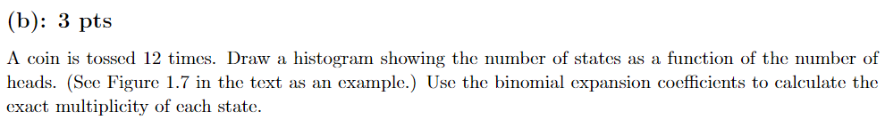

The height of each bar is found using nCr. My drawing skills are not great.

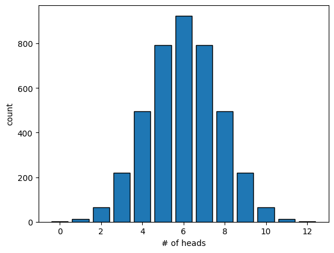

```python
import matplotlib.pyplot as plt
from math import comb #nCr

plt.bar(range(0,13), [comb(12, i) for i in range(13)], edgecolor='black')
plt.xlabel('# of heads')
plt.ylabel('count')
```

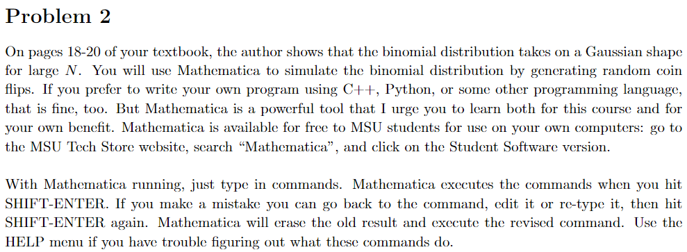

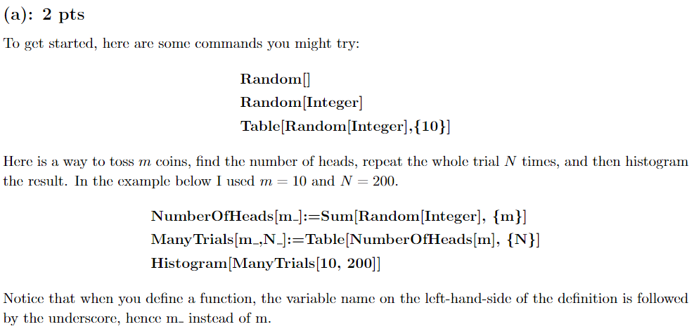

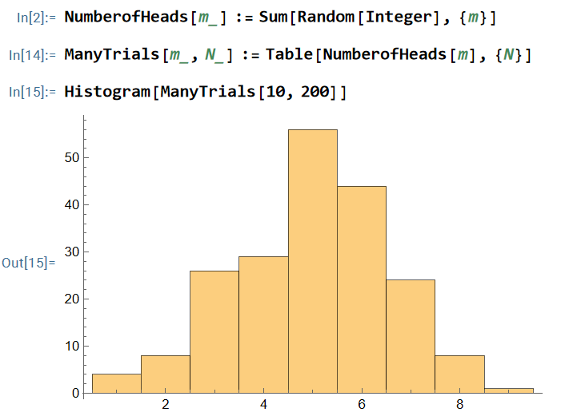

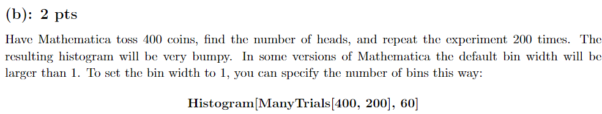

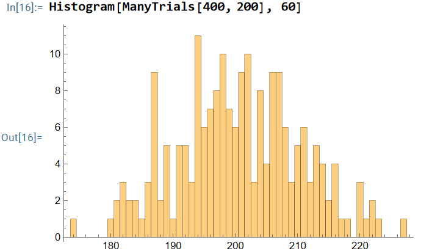

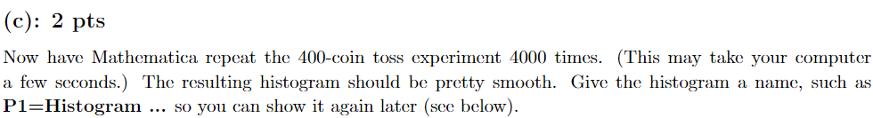

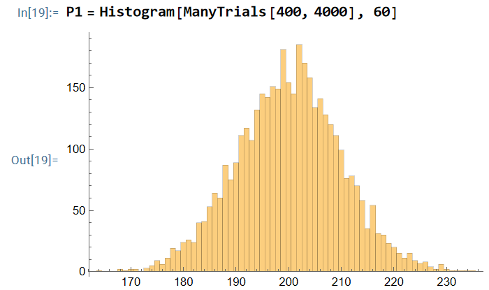

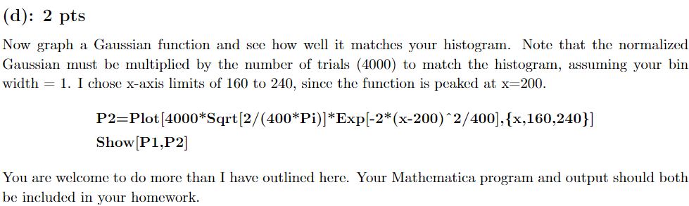

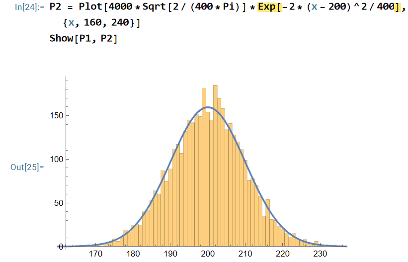

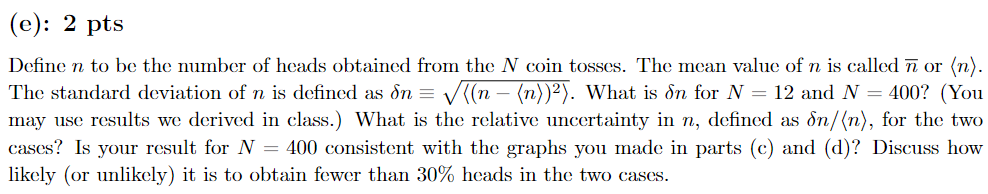

Using binomial $\delta n = \sqrt{np(1-p)}$, where $p=0.5$, we have $$ \begin{matrix} N=12 & \delta n = \sqrt{12*.25} = \sqrt{3} \approx 1.7 \\ & \frac{\delta n}{\langle n \rangle} = \sqrt{3}/6 \approx 0.29 \\ N=400 & \delta n = \sqrt{400*.25} = 10 \\ & \frac{\delta n}{\langle n \rangle} = 10/200 = 0.05 \end{matrix} $$ From this we can tell it's much less likey to obtain fewer than 30% for N=400 compared to N=12, as the relative uncertainty is much smaller.

Using a binomial distribution calculator, we see the odds for N=12 <30% (0-3 coins) is .07, but for N=400 <30% (0-119 coins) is $10^{-16}$

```python
result = 0
for i in range(120):
    result += comb(400, i) * .5**i * (.5)**(400-i)
result
```

```
1.6229650967488738e-16
```

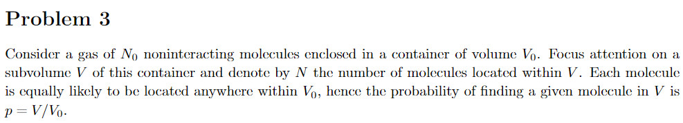

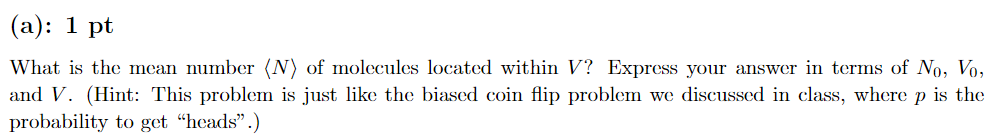

$\langle N \rangle = N_0 p = N_0 \frac{V}{V_0}$

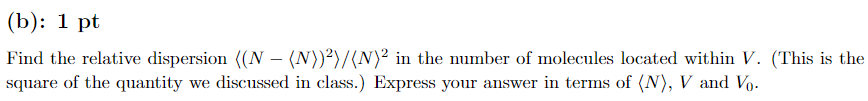

Binomial distribution variance: $npq$

$$ \langle ( N-\langle N \rangle)^2 \rangle = N_0 \frac{V}{V_0}\left(1-\frac{V}{V_0} \right) \\ = \langle N \rangle\left(1-\frac{V}{V_0} \right) \\ \frac{\langle ( N-\langle N \rangle)^2 \rangle}{\langle N \rangle^2} = \frac{\langle N \rangle }{\langle N \rangle^2}\left(1-\frac{V}{V_0} \right) \\ = \frac{1-\frac{V}{V_0}}{\langle N \rangle} \\ = \frac{1-\frac{V}{V_0}}{N_0 \frac{V}{V_0}} = \frac{1}{N_0\frac{V}{V_0}}-\frac{1}{N_0} $$

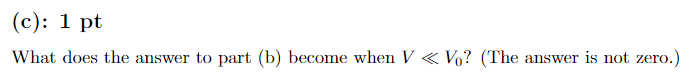

Since the $\frac{1}{N_0\frac{V}{V_0}}$ term blows up, the relative dispersion becomes very large. The answer approaches $\frac{1}{\langle N \rangle}$, and $\langle N \rangle$ becomes quite small

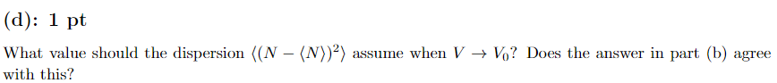

This should approach zero, which my answer agrees with. $1-\frac{V}{V_0}$ will approach zero and so will the dispersion.

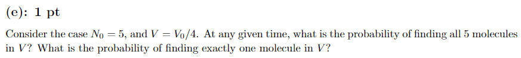

Base probability $p = V/V_0 = 1/4$

All five in: $p(\text{all 5 in}) = p^5 = 1/4^5 = 1/1024 \approx .001$  
One in can be achieved 5 ways: $p(\text{one in}) = 5*p*(1-p)^4 = 5/4*(3/4)^4= 405/1024 \approx .4$